# Atomのインストールと設定

> オブジェクト指向プログラミングおよび演習1 第1回

# 事前注意

テキストエディタは、文字コードでUTF-8形式の保存、改行コードの切り替えが可能であれば、基本的になんでも良いです。

講義内では基本的にAtomを使用して解説いたしますので、こだわりがなければAtomをインストールしてください。 もし、宗教上(Emacs教やVim信者など)の理由でAtomを使いたくない場合は、Atomを使用せず、自分にあったテキストエディタをお使いください。

VSCodeのように最近シェアを多く獲得しているテキストエディタもとても優秀で、個人的にはおすすめなのですが、優秀すぎるが故に講義でプログラミングを教える際に邪魔となってしまう機能があります。 講義の途中から、統合開発環境を用いた開発に切り替えますので、趣味での開発を行う場合などには、AtomよりもVSCodeを使うと良いかも知れません。Atomは、統合開発環境での開発が始まったら不要となりますので削除するしないはご自由にどうぞ。

## 配布元よりダウンロード

配布元： [Atom](https://atom.io/)

## インストール

ダウンロードした`atom-mac.zip`を展開し、展開された`Atom.app`を`アプリケーション`フォルダに移動してください。

[figure not shown]

## Atomを開く

Lunchpadでもなんでもいいので、Atomを開きます。

## terminalで「atom」コマンドが使えるようにする

Atomを起動したら、まずは以下の画面にしたがってShellコマンドをインストールしてください。

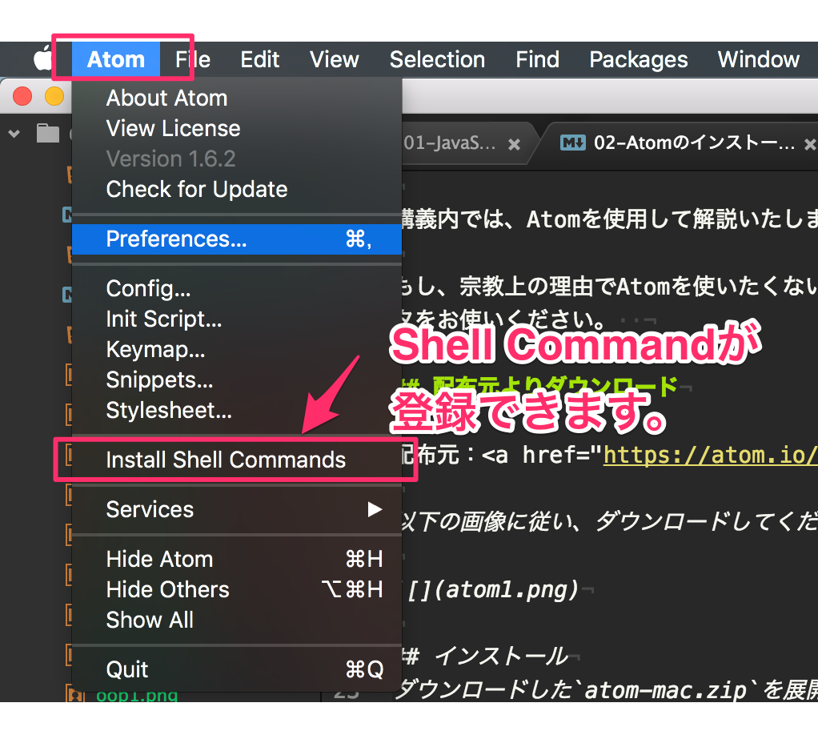

## 各種設定を行う

初回起動時には、最初から開かれているかもしれません。

もし開いていない場合は、以下の画像を参照して、設定画面を開いてください。

[figure not shown]

## メニューを日本語化する(英語のままで良い場合は飛ばしてください。)

メニューバーより[Atom]→[Preferences…]を選択してください。

[figure not shown]

設定画面が開いたら、以下の画像のように、「japanese-menu」をインストールします。

[figure not shown]

「Install」ボタンを押したら、インストールが完了するまで待ちましょう。 インストールが完了したら、atom再起動後にメニューバーや設定画面が日本語になっているはずです。

### パッケージについて

Atomでは、様々なパッケージが有志より提供されており、開発をより簡単に行えるように機能を拡張することが可能です。 必要に応じてインストールしていただいて構いませんが、この講義では、これ以上のパッケージについては指定しません。

## (任意)Atomエディタのフォントをプログラミング用フォントに変更する

### プログラミング用フォント「Ricty Diminished」のインストール

[GitHub : Ricty Diminished - fonts for programming](https://github.com/edihbrandon/RictyDiminished)

1. 緑色のボタンより、「Download ZIP」をクリック。 または、moodleにリソースとして置いておきます。
2. ダウンロードしたファイルを展開。
3. `.ttf`のファイルをすべて選択。
4. 右クリックメニューからFont Bookで開く。
5. 2つ出てくるウィンドウの両方を「インストール」ボタンでインストール。

### Atomの標準フォントを変更する

設定画面の「エディタ設定」より、以下のようにフォントの設定を変更してください。

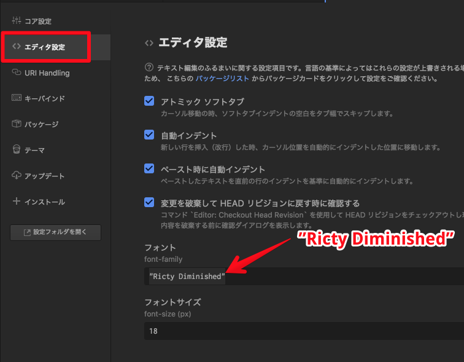

### フォントにRicty Diminishedを使用する理由

プログラミングをテキストエディタで行う場合、日本語環境下では全角スペースと半角スペースを間違えるなど、全角/半角での視認性の問題が必ず発生します。

RictyDiminishedでは、全角スペースなどの間違えやすい特殊文字を以下のように分かりやすく表示してくれます。

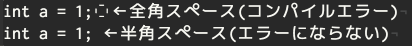

コードを書く上での不安要素を排除しておきたい方はインストールをしておくことをおすすめします。

## 以上で設定は完了です。

まだJavaの開発環境を用意できていなければ、資料を参考にJava開発環境のインストールを進めて下さい。